# Estudo a partir de dados da embarcação de pessoas no Titanic

Jadson Luan, Jessé Souza e Lucas Medeiros

1 de julho de 2019

## Descrição a respeito dos dados

Para esse estudo, foi utilizado um arquivo contendo dados de 891 tripulantes do navio Titanic, que afundou na madrugado do dia 15 de abril de 1912, logo após ter colidido com um iceberg, onde das 2224 pessoas a bordo do navio, entre tripulantes, operários e oficiais, somente 710 sobreviveram. Nosso objetivo, então, foi a partir da análise dos dados de 7 das variáveis presentes nesse dataset, identificar se houve influencia de um ou mais fatores na sobrevivência, ou não, do passageiro.

## Descrição das variáveis

- **survived**: se uma pessoa que embarcou no Titanic sobreviveu à tragédia ou não, seguindo o modelo abaixo:
  - “1”, caso tenha sobrevivido.
  - “0”, caso contrário.
- **pclass:** classe socio-econômica do passageiro
  - “1”, caso seja da Classe alta
  - “2”, caso seja da Classe média
  - “3”, caso seja da Classe baixa
- **sex:** sexo do passageiro
  - “1”, caso seja Mulher
  - “0”, caso seja Homem
- **fare:** tarifa paga pelo passageiro para embarcar
- **sibsp:** número de irmãos/cônjuges do passageiro abordo do Titanic
  - O *dataset* define relações familiares da seguinte forma…
    - Irmãos = irmão, irmã, meio-irmão, meia-irmã
    - Cônjuge = marido, esposa (amantes e noivos/noivas foram ignorados)
- **parch:** número de pais / filhos do passageiro abordo do Titanic
  - O *dataset* define relações familiares da seguinte forma…
    - Pais = mãe, pai
    - Filhos = filho, filha, neto, neta

# Análise descritiva

### Gráficos de barra (sobreviventes)

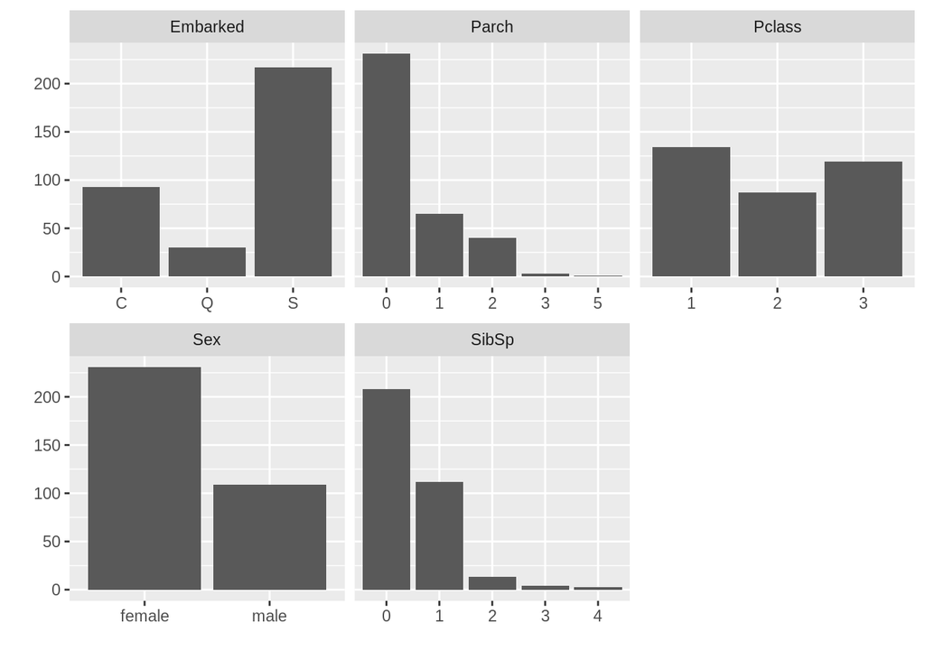

### Gráficos de barra (não-sobreviventes)

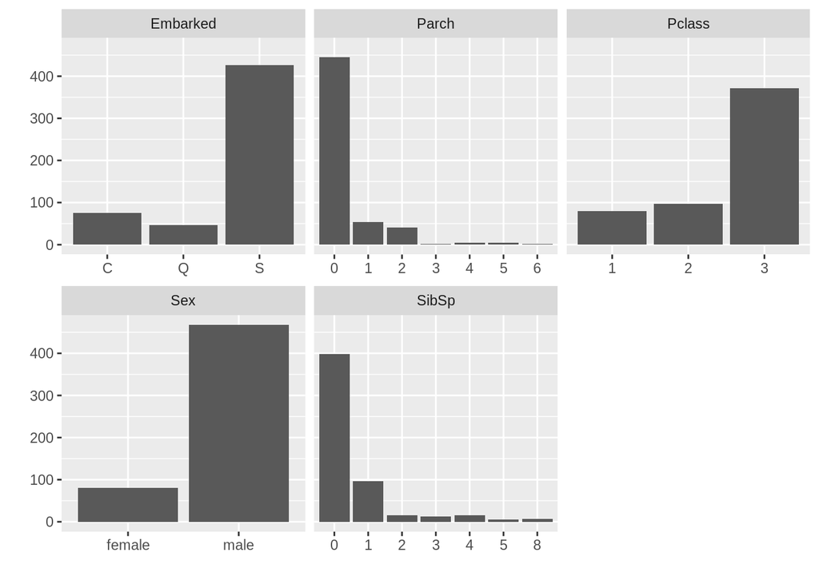

### Dispersão das variáveis

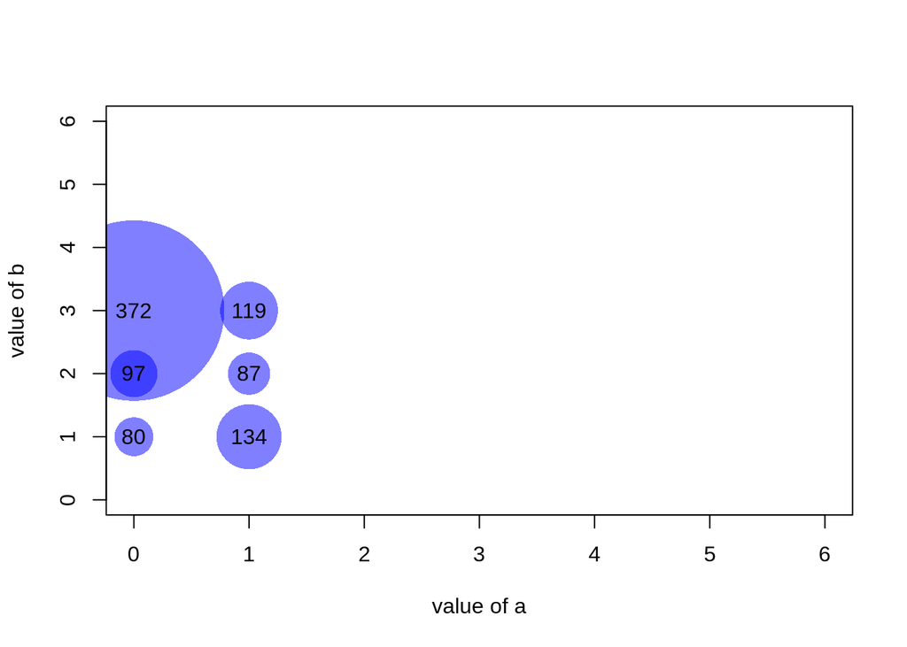

```r
a=c(1,1,3,4,5,5,1,1,2,3,4,1,3,2,1,1,5,1,4,3,2,3,1,0,2)
b=c(1,2,3,5,5,5,2,1,1,3,4,3,3,4,1,1,4,1,4,2,2,3,0,0,1)

#I count the occurence of each couple of values. Eg : number of time a=1 and b=1, number of time a=1 and b=2 etc...
AA=xyTable(data$Survived, data$Pclass)

#Now I can plot this ! I represent the dots as big as the couple occurs often
coeff_bigger=0.05
plot(AA$x , AA$y , cex=AA$number*coeff_bigger  , pch=16 , col=rgb(0,0,1,0.5) , xlab= "value of a" , ylab="value of b" , xlim=c(0,6) , ylim=c(0,6) )
text (AA$x , AA$y , AA$number )
```

[figure not shown]

[figure not shown]

[figure not shown]

[figure not shown]

```r
#Note : It's easy to make a function that will compute this kind of plot automaticaly :
represent_discrete_variable=function(var1, var2 , coeff_bigger){
  AA=xyTable(var1,var2)
  plot(AA$x , AA$y , cex=AA$number*coeff_bigger  , pch=16 , col="chocolate1" , xlab= "Sobreviveu?" , ylab="value of b" )
  text (AA$x , AA$y , AA$number )
}
```

## Análise da correlação geral

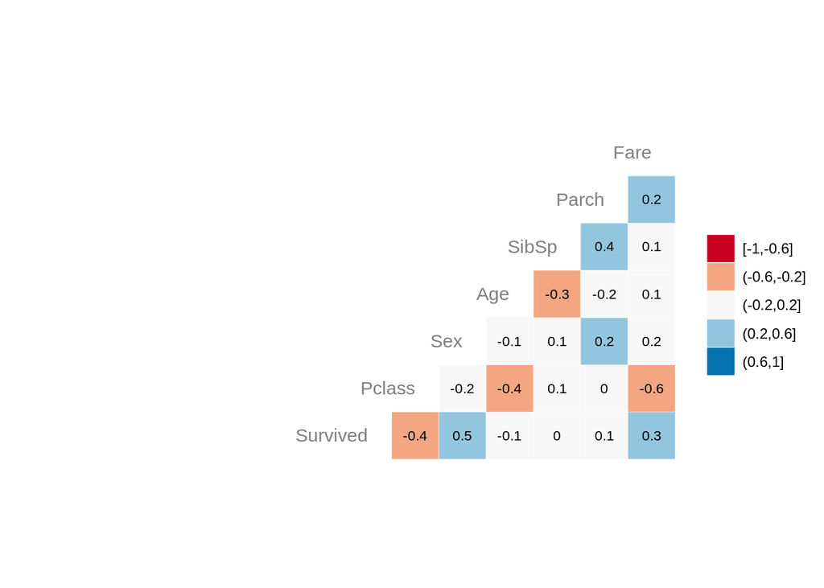

## Correlações das variáveis selecionadas

```r
cor(titanic_data$Survived, titanic_data$Pclass)
```

```
## [1] -0.3596527
```

```r
cor(titanic_data$Survived, titanic_data$Fare)
```

```
## [1] 0.2681886
```

```r
cor(titanic_data$Survived, titanic_data$Sex)
```

```
## [1] 0.5388256
```

## Análise das correlações das variáveis selecionadas

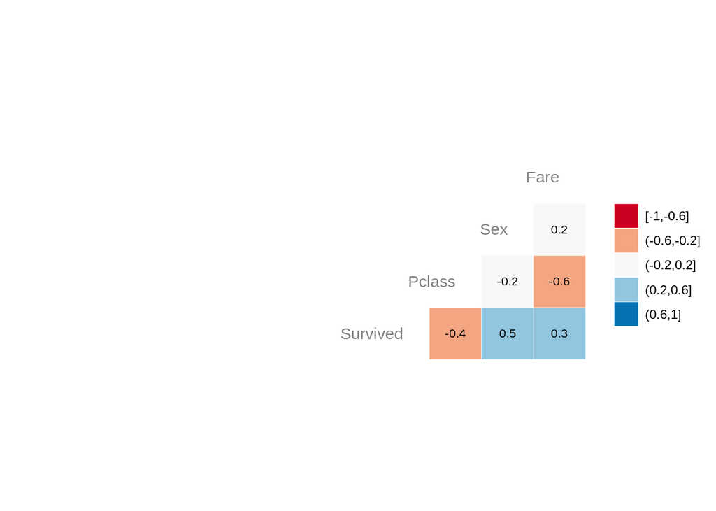

## Comportamento dos dados em relação à sobrevivência

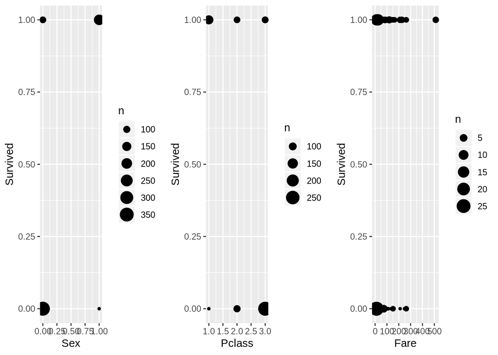

# Criando modelo de regressão linear

## Iniciando um modelo de regressão com todas variáveis

Usando a abordagem *backward* temos um modelo com as três variáveis preditivas selecionadas. Iremos definir como nível de significância 5%.

## Modelo de regressão inicial

```r
model <- lm(formula = Survived ~ Sex + Fare + Pclass, data = titanic_data)
tidy(model)
```

| term | estimate | std.error | statistic | p.value |
| --- | --- | --- | --- | --- |
| (Intercept) | 0.5634735740 | 0.05764463 | 9.7749536 | 2.941702e-21 |
| Sex | 0.5016501423 | 0.03100275 | 16.1808275 | 2.307730e-50 |
| Fare | 0.0002714781 | 0.00033506 | 0.8102371 | 4.180754e-01 |
| Pclass | -0.1565283918 | 0.02104317 | -7.4384429 | 2.947284e-13 |

## Análise ANOVA

```r
anova(model)
```

|  | Df | Sum Sq | Mean Sq | F value | Pr(>F) |
| --- | --- | --- | --- | --- | --- |
| Sex | 1 | 49.999087 | 49.9990870 | 326.63820 | 2.369614e-60 |
| Fare | 1 | 5.063313 | 5.0633135 | 33.07804 | 1.315736e-08 |
| Pclass | 1 | 8.469527 | 8.4695273 | 55.33043 | 2.947284e-13 |
| Residuals | 710 | 108.680957 | 0.1530718 | NA | NA |

# Teste F

## Removendo a variável ‘fare’

Ao analisar as variáveis do modelo, primeiramente partimos da hipótese nula de que os coefientes do mesmo são iguais a zero, ou seja, a variável é irrelevante para o modelo. Com isso em mãos, verificamos o p-valor a fim de negar ou comprovar tal hipótese, ou seja, caso o p-valor da variável seja maior que o nível de significância (> 0.05), significa que a hipótese nula é verdadeira e com isso removemos a variável do modelo. A partir da análise dos p-valores das variáveis do modelo, podemos perceber que a variável ‘Fare’ possui um p-valor (~0.418) maior que o nível de significância fixado, então decidimos removê-la do nosso modelo.

## Novo modelo de regressão

```r
model <- lm(formula = Survived ~ Sex + Pclass, data = titanic_data)
tidy(model)
```

| term | estimate | std.error | statistic | p.value |
| --- | --- | --- | --- | --- |
| (Intercept) | 0.5924288 | 0.04521949 | 13.101181 | 2.769184e-35 |
| Sex | 0.5046696 | 0.03077052 | 16.401076 | 1.638742e-51 |
| Pclass | -0.1657564 | 0.01769037 | -9.369867 | 9.430448e-20 |

## Calculando o R-quadrado

```
## [1] 0.3683315
```

O valor rQuadrado de 0.3683315 significa que apenas 36.83% dos dados, aproximadamente, estão sendo representados por esse modelo, valor que pode ser considerado mediano-baixo.

## Interpretação do Modelo resultante

O modelo resultante pode ser representado como sendo:

Y = 0.592 + 0.505 * Sex - 0.166 * Pclass

## Análise dos resíduos

### Teste de homogeniedade

Pelo comportamento da linha vermelha, é possivel perceber a não homogenuidade dos resíduos

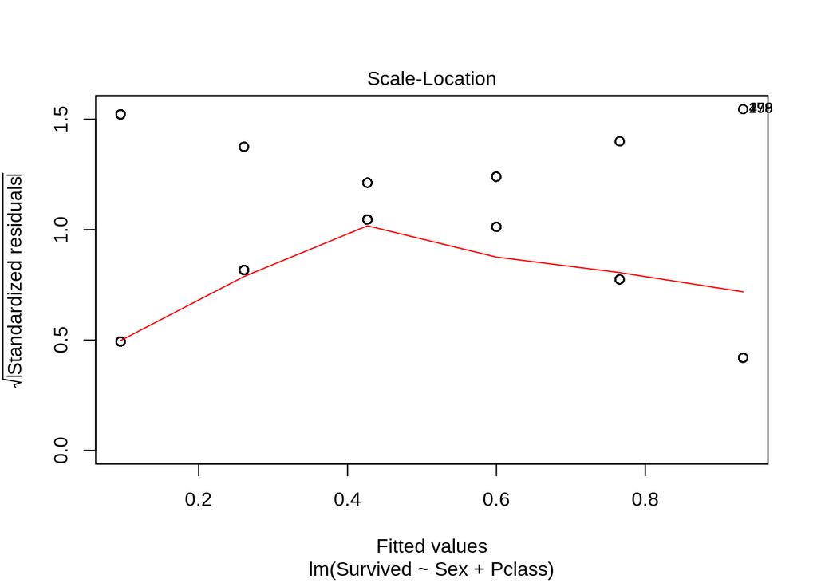

```r
plot(model, which=3, col=c("black"))
```

### Teste de linearidade

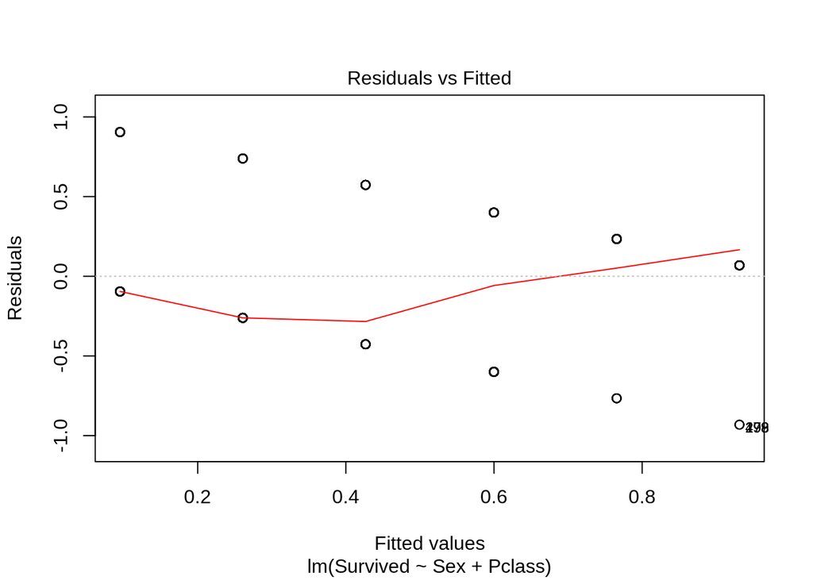

```r
plot(model, which=1, col=c("black"))
```

### Teste de normalidade

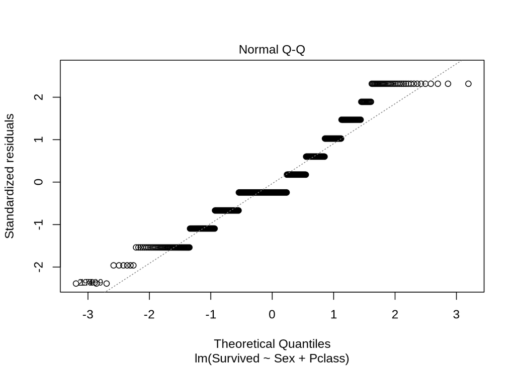

```r
plot(model, which=2, col=c("black"))
```

### Teste De Shapiro-Wilk

Usando o teste de Shapiro-Wilk para avaliar se a amostra tem distribuição normal, temos:

```r
shapiro.test(residuals(model))
```

```
##
##  Shapiro-Wilk normality test
##
## data:  residuals(model)
## W = 0.94463, p-value = 1.113e-15
```

## Conclusão

A partir do modelo obtido, é possivel analisar que caso o dado seja do sexo feminino (Sex = 1), a probabilidade do mesmo de sobreviver é muito maior, o que pode ser afetado com a diminuição da classe em que você estava viajando. Tais dados, mesmo possuindo apenas 36.83% de representatividade dentro da amostra, demonstra bem a situação real que ocorreu no navio, pois uma vez que foi comandada a evacuação, muitos dos oficiais usaram a regra de embarcar primeiro mulheres e crianças.